**Loading and preprocessing the data**

```r
library(knitr)
opts_chunk$set(echo=T)
```

```r
setwd("C:/Users/Sergey/Documents/R/coursera/Reproducible research/week 1 assign")
url="http://d396qusza40orc.cloudfront.net/repdata%2Fdata%2Factivity.zip"
download.file(url, destfile="source.zip",mode="wb")
source_file <- unzip("source.zip", files ="activity.csv")
activity<-read.csv(source_file, sep=",",header=T)
activity$date <- as.Date(activity$date, format= "%Y-%m-%d")
act_noNA<-activity[(!is.na(activity$steps)),]
```

**What is mean total number of steps taken per day?** Histogramm for steps-by-day

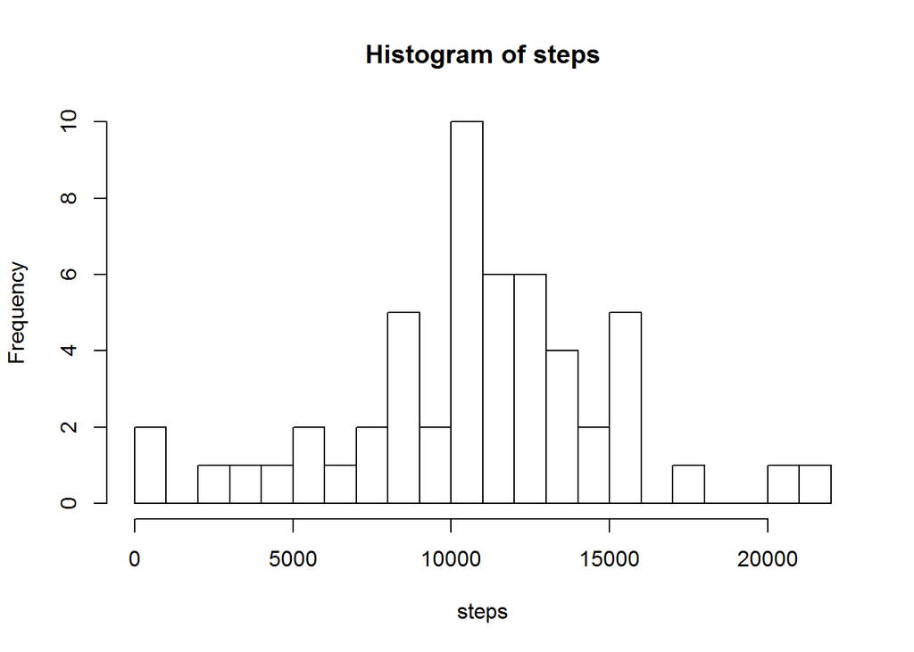

```r
steps<-tapply(act_noNA$steps,act_noNA$date, sum, simplify=T)
hist(steps, breaks=20)
```

*Mean, median and other stats for steps-by-day.*

Mean=10770, median=10760

```r
summary(steps)
```

```
##    Min. 1st Qu.  Median    Mean 3rd Qu.    Max.
##      41    8841   10760   10770   13290   21190
```

**What is the average daily activity pattern?**

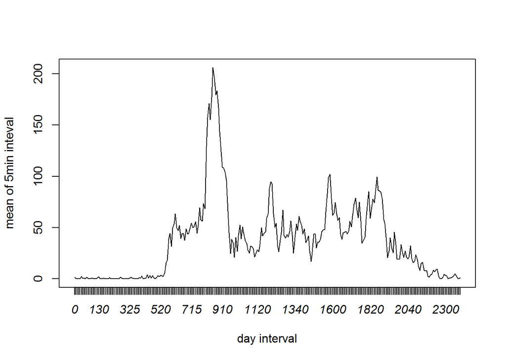

```r
mean5min <- tapply(act_noNA$steps, act_noNA$interval,mean)
plot(mean5min, type="l", xaxt="n", xlab="day interval", ylab= "mean of 5min inteval")
axis(side=1,at=as.vector(1:length(mean5min)),labels=as.vector(names(mean5min)),
     font=3)
```

At 8.35 interval the mean amount of steps is maximum (206)

```r
mean5min[mean5min==max(mean5min)]
```

```
##      835
## 206.1698
```

**Imputing missing values**

Number of NA values

```r
sum(is.na(activity$steps))
```

```
## [1] 2304
```

New dataset is the original dataset with the missing data filled in

```r
act_NArepl <- activity
for (i in 1:length(act_NArepl$steps)) {
    if (is.na(act_NArepl$steps[i])) {
        act_NArepl$steps[i] <-
            mean(subset(activity$steps,activity$interval==act_NArepl$interval[i]),na.rm=T)
    }
}
```

Mean and median values are identical for the chosen way of NAs imputing and equal 10766 steps per day. So this change t original data doesn’t change mean and median values significantly.

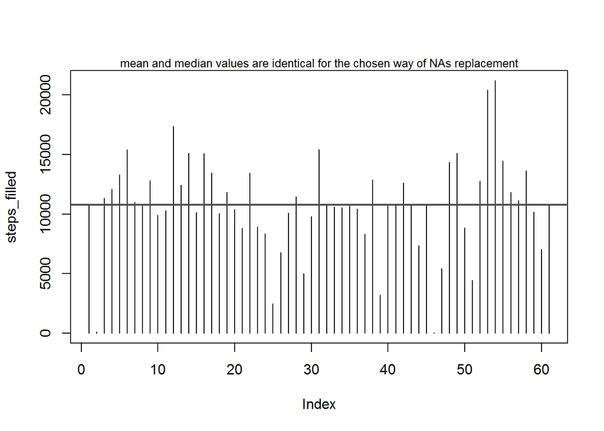

```r
steps_filled<-tapply(act_NArepl$steps,act_NArepl$date, sum, simplify=T)
plot(steps_filled,type="h", lwd=1)
if (mean(steps_filled)==median(steps_filled)) {
    abline(h=mean(steps_filled), lwd=2, col="grey30")
    mtext("mean and median values are identical for the chosen way of NAs replacement", cex=0.8)
} else {
    abline(h=mean(steps_filled), lwd=2, col="grey30")
    abline(h=median(steps_filled), lwd=2, col ="grey67")
}
```

**Are there differences in activity patterns between weekdays and weekends?**

New factor variable weekday_f. Aggregating by factor var and interval

```r
install.packages("lubridate",repos="http://R-Forge.R-project.org")
library(lubridate)
weekday<-wday(act_NArepl$date, label=F)
weekday_f<-NULL
weekday_f[weekday==1|weekday==7]<-"weekend"
weekday_f[weekday>1 & weekday < 7]<-"workday"
act_wday <- cbind(act_NArepl,weekday_f)
aggr_steps<-aggregate(steps~interval+weekday_f , data=act_wday, mean)
```

*There is a difference in activity pattern:*

- during the workdays morning peak is pretty above 200 steps which is substantially higher than weekend value (~170 steps)
- after the morning peak the activity level is higher during the weekend than during the workdays.

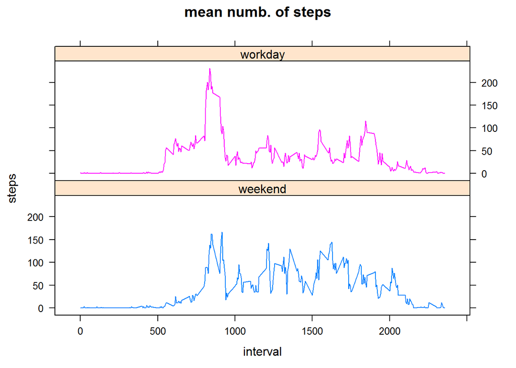

```r
library(lattice)
xyplot(steps~interval|weekday_f,data=aggr_steps,type="l",layout=c(1,2),
       groups=weekday_f, main="mean numb. of steps")
```